# Case_Study_02_Grace_Lang

Grace Lang

8/1/2019

# Introduction

DDS Analytics has been contracted by Frito Lay to do the following: build a model that helps predict attrition for employees, reveal top 3 factors that lead to attrition, and understand some common trends of employees who decide to leave the company.

# Data Importing & Cleaning

Frito Lay provided a sample dataset that includes around 870 employees with a flag on whether or not they left the company. Around 16% of the 870 employees left the company. It is unclear on the timeframe of the employee data-pull.

# Data Setup

Read in the data; details on how to read in the data are found within the .Rmd file.

### Explore the structure of the data

The average Total Worked Years is 11.05 years compared to only 6.96 years at Frito Lay and an average of 4.2 years in their current role. Also, the average time since the employee’s last promotion is around 2.2 years. The average Age of the employees is 37 years. The majority of the dataset work as a Sales Executive, a Research Scientist or a Lab Technician.

The Hourly average rate is $65.61/hour. The average Monthly Rate is $14,326/month. The average Monthly Income is $6,390/month.

Below are histograms of Hourly Rate and Monthly income of the employees surveyed.

```r
str(Initial)
```

```
## 'data.frame':    870 obs. of  37 variables:
##  $ X                       : int  1 2 3 4 5 6 7 8 9 10 ...
##  $ ID                      : int  1 2 3 4 5 6 7 8 9 10 ...
##  $ Age                     : int  32 40 35 32 24 27 41 37 34 34 ...
##  $ Attrition               : Factor w/ 2 levels "No","Yes": 1 1 1 1 1 1 1 1 1 1 ...
##  $ BusinessTravel          : Factor w/ 3 levels "Non-Travel","Travel_Frequently",..: 3 3 2 3 2 2 3 3 3 2 ...
##  $ DailyRate               : int  117 1308 200 801 567 294 1283 309 1333 653 ...
##  $ Department              : Factor w/ 3 levels "Human Resources",..: 3 2 2 3 2 2 2 3 3 2 ...
##  $ DistanceFromHome        : int  13 14 18 1 2 10 5 10 10 10 ...
##  $ Education               : int  4 3 2 4 1 2 5 4 4 4 ...
##  $ EducationField          : Factor w/ 6 levels "Human Resources",..: 2 4 2 3 6 2 4 2 2 6 ...
##  $ EmployeeCount           : int  1 1 1 1 1 1 1 1 1 1 ...
##  $ EmployeeNumber          : int  859 1128 1412 2016 1646 733 1448 1105 1055 1597 ...
##  $ EnvironmentSatisfaction : int  2 3 3 3 1 4 2 4 3 4 ...
##  $ Gender                  : Factor w/ 2 levels "Female","Male": 2 2 2 1 1 2 2 1 1 2 ...
```

[output cut: 23 more lines]

```r
summary(Initial)
```

```
##        X               ID             Age        Attrition
##  Min.   :  1.0   Min.   :  1.0   Min.   :18.00   No :730
##  1st Qu.:218.2   1st Qu.:218.2   1st Qu.:30.00   Yes:140
##  Median :435.5   Median :435.5   Median :35.00
##  Mean   :435.5   Mean   :435.5   Mean   :36.83
##  3rd Qu.:652.8   3rd Qu.:652.8   3rd Qu.:43.00
##  Max.   :870.0   Max.   :870.0   Max.   :60.00
##
##            BusinessTravel   DailyRate                       Department
##  Non-Travel       : 94    Min.   : 103.0   Human Resources       : 35
##  Travel_Frequently:158    1st Qu.: 472.5   Research & Development:562
##  Travel_Rarely    :618    Median : 817.5   Sales                 :273
##                           Mean   : 815.2
##                           3rd Qu.:1165.8
##                           Max.   :1499.0
##
##  DistanceFromHome   Education              EducationField EmployeeCount
##  Min.   : 1.000   Min.   :1.000   Human Resources : 15    Min.   :1
##  1st Qu.: 2.000   1st Qu.:2.000   Life Sciences   :358    1st Qu.:1
##  Median : 7.000   Median :3.000   Marketing       :100    Median :1
##  Mean   : 9.339   Mean   :2.901   Medical         :270    Mean   :1
##  3rd Qu.:14.000   3rd Qu.:4.000   Other           : 52    3rd Qu.:1
##  Max.   :29.000   Max.   :5.000   Technical Degree: 75    Max.   :1
##
##  EmployeeNumber   EnvironmentSatisfaction    Gender      HourlyRate
##  Min.   :   1.0   Min.   :1.000           Female:354   Min.   : 30.00
##  1st Qu.: 477.2   1st Qu.:2.000           Male  :516   1st Qu.: 48.00
##  Median :1039.0   Median :3.000                        Median : 66.00
##  Mean   :1029.8   Mean   :2.701                        Mean   : 65.61
##  3rd Qu.:1561.5   3rd Qu.:4.000                        3rd Qu.: 83.00
##  Max.   :2064.0   Max.   :4.000                        Max.   :100.00
##
##  JobInvolvement     JobLevel                          JobRole
##  Min.   :1.000   Min.   :1.000   Sales Executive          :200
##  1st Qu.:2.000   1st Qu.:1.000   Research Scientist       :172
##  Median :3.000   Median :2.000   Laboratory Technician    :153
##  Mean   :2.723   Mean   :2.039   Manufacturing Director   : 87
##  3rd Qu.:3.000   3rd Qu.:3.000   Healthcare Representative: 76
##  Max.   :4.000   Max.   :5.000   Sales Representative     : 53
##                                  (Other)                  :129
```

[output cut: 25 more lines]

```
##  Min.   :0.000         Min.   :1.000   Min.   : 0.000   Min.   : 0.000
##  1st Qu.:2.000         1st Qu.:2.000   1st Qu.: 3.000   1st Qu.: 2.000
##  Median :3.000         Median :3.000   Median : 5.000   Median : 3.000
##  Mean   :2.832         Mean   :2.782   Mean   : 6.962   Mean   : 4.205
##  3rd Qu.:3.000         3rd Qu.:3.000   3rd Qu.:10.000   3rd Qu.: 7.000
##  Max.   :6.000         Max.   :4.000   Max.   :40.000   Max.   :18.000
##
##  YearsSinceLastPromotion YearsWithCurrManager
##  Min.   : 0.000          Min.   : 0.00
##  1st Qu.: 0.000          1st Qu.: 2.00
##  Median : 1.000          Median : 3.00
##  Mean   : 2.169          Mean   : 4.14
##  3rd Qu.: 3.000          3rd Qu.: 7.00
##  Max.   :15.000          Max.   :17.00
##
```

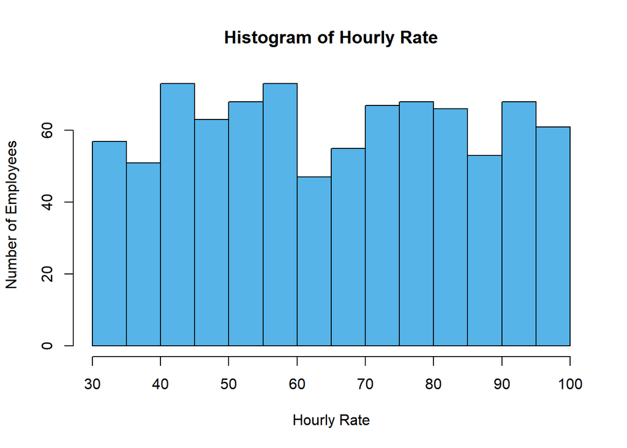

```r
hist(Initial$HourlyRate, col = "#56B4E9", xlab="Hourly Rate", ylab = "Number of Employees", main="Histogram of Hourly Rate")
```

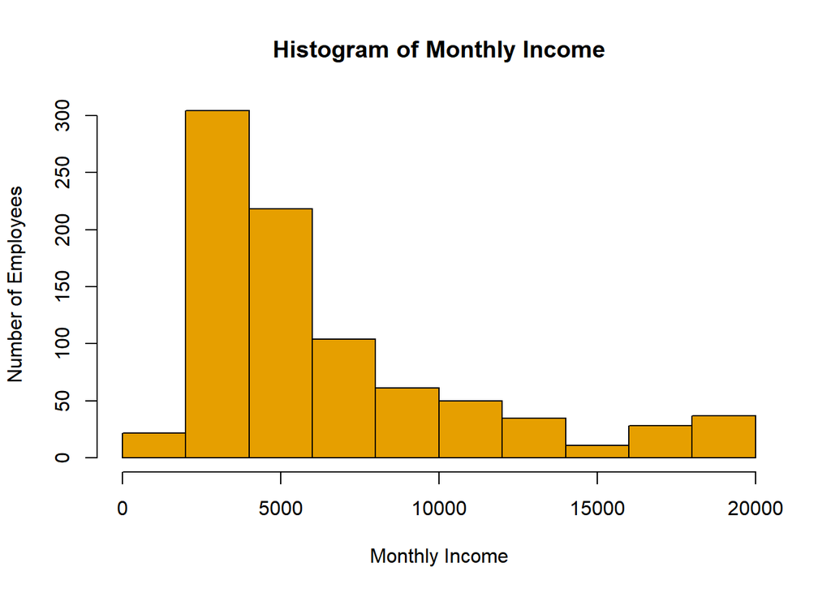

```r
hist(Initial$MonthlyIncome, col = "#E69F00", xlab="Monthly Income", ylab = "Number of Employees", main="Histogram of Monthly Income")
```

Drop columns that wont add value to analysis:  
* ID = row number  
* EmployeeCount = 1  
* Over18 = Y  
* StandardHours = 80

```r
Initial$ID <- NULL
Initial$X <- NULL
Initial$EmployeeCount <- NULL
Initial$Over18 <- NULL
Initial$StandardHours <- NULL
```

Descriptive Statistics & Creation of New Variables

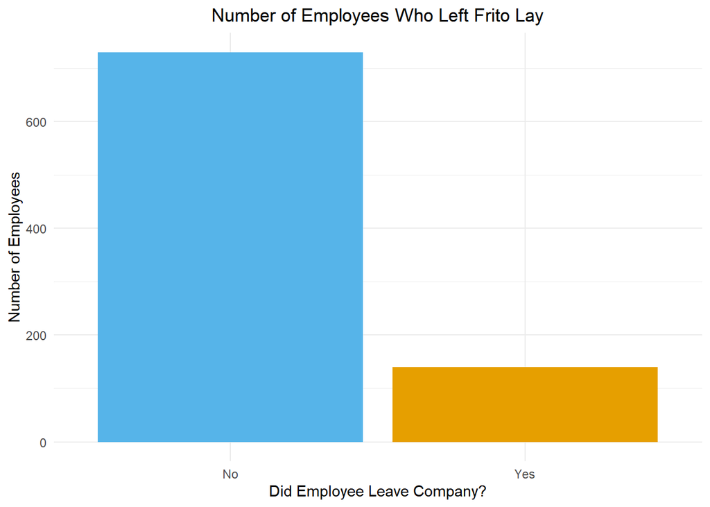

```r
library(ggthemes)
Palette <- c("#56B4E9","#E69F00")

ggplot(Initial, aes(Attrition,fill=Attrition)) + geom_bar(fill = Palette ) + theme_minimal() + theme(plot.title = element_text(hjust=0.5), legend.position ="none") + labs(x="Did Employee Leave Company?", y="Number of Employees", title = "Number of Employees Who Left Frito Lay")
```

```r
#16 % of dataset are employees who left the company
prop.table(table(Initial$Attrition))
```

```
##
##        No       Yes
## 0.8390805 0.1609195
```

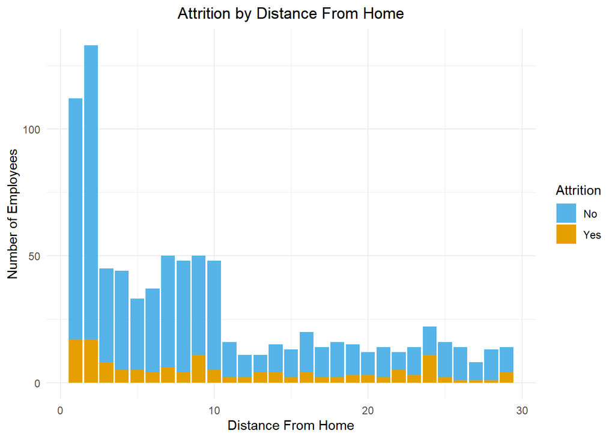

```r
#Employees who live 11 - 25 miles from work have a higher attrition rate
ggplot(Initial, aes(DistanceFromHome,fill=Attrition)) + geom_bar() + theme_minimal() + theme(plot.title = element_text(hjust=0.5)) + labs(x="Distance From Home", y="Number of Employees", title = "Attrition by Distance From Home") + scale_fill_manual(values = Palette)
```

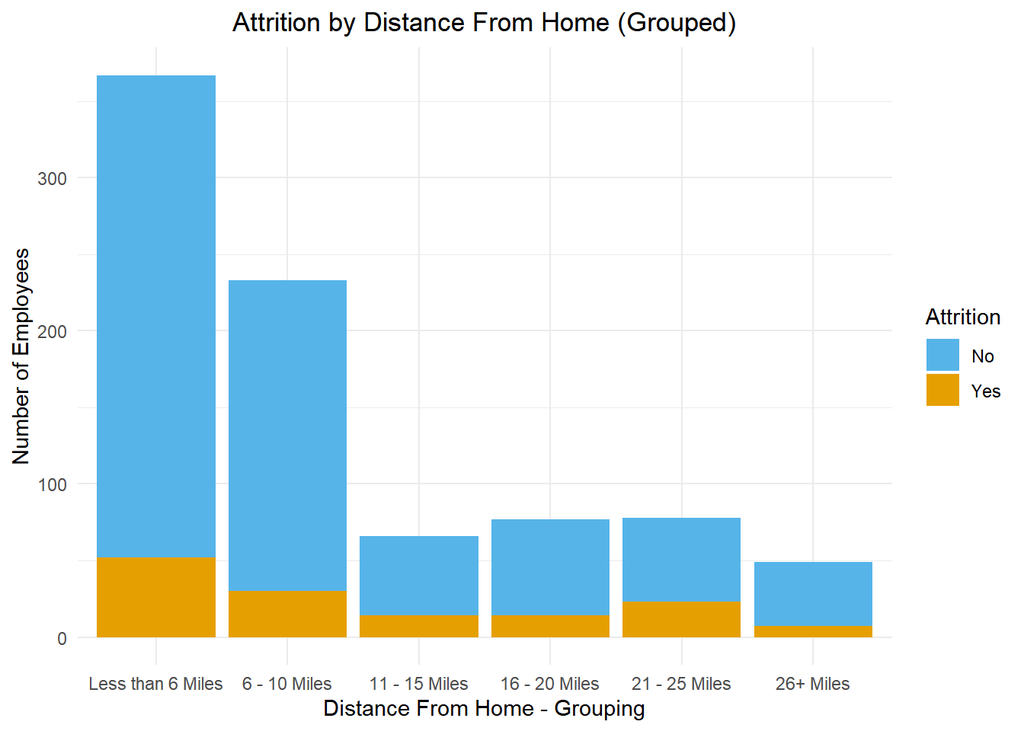

```r
#Creating a Distance Group
Initial$DistanceGroup <- with(Initial,ifelse(DistanceFromHome>25,"26+ Miles",ifelse(DistanceFromHome>20,"21 - 25 Miles",ifelse(DistanceFromHome>15,"16 - 20 Miles",ifelse(DistanceFromHome>10,"11 - 15 Miles",ifelse(DistanceFromHome>5,"6 - 10 Miles","Less than 6 Miles"))))))

ggplot(Initial, aes(x=reorder(DistanceGroup,DistanceFromHome),fill=Attrition)) + geom_bar() + theme_minimal() + theme(plot.title = element_text(hjust=0.5)) + labs(x="Distance From Home - Grouping", y="Number of Employees", title = "Attrition by Distance From Home (Grouped)") + scale_fill_manual(values = Palette)
```

```r
prop.table(table(Initial$Attrition, Initial$DistanceGroup),2)
```

```
##
##       11 - 15 Miles 16 - 20 Miles 21 - 25 Miles 26+ Miles 6 - 10 Miles
##   No      0.7878788     0.8181818     0.7051282 0.8571429    0.8712446
##   Yes     0.2121212     0.1818182     0.2948718 0.1428571    0.1287554
##
##       Less than 6 Miles
##   No          0.8583106
##   Yes         0.1416894
```

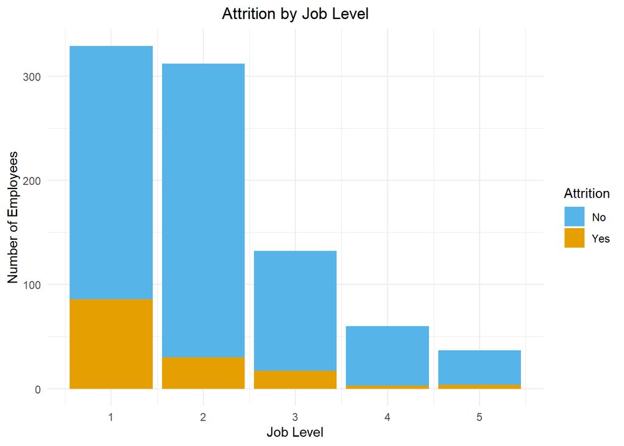

```r
#As job level increases the amount of people who leave decreases
ggplot(Initial, aes(JobLevel,fill=Attrition)) + geom_bar() + theme_minimal() + theme(plot.title = element_text(hjust=0.5)) + labs(x="Job Level", y="Number of Employees", title = "Attrition by Job Level") + scale_fill_manual(values = Palette)
```

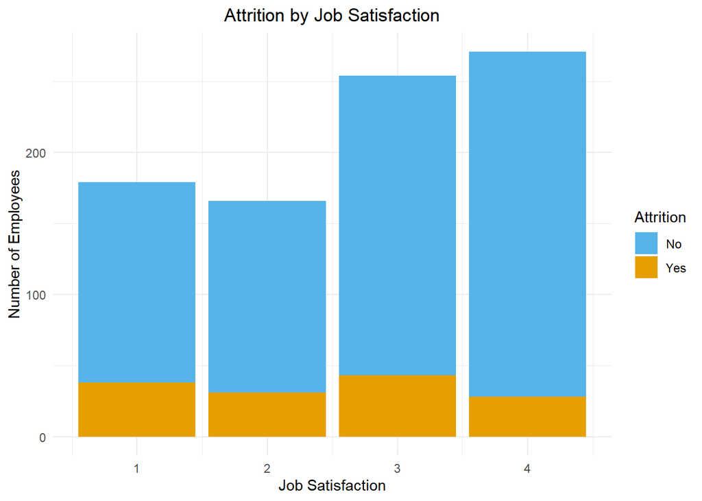

```r
#There are higher rates of attrition with lower job satisfaction
ggplot(Initial, aes(JobSatisfaction,fill=Attrition)) + geom_bar() + theme_minimal() + theme(plot.title = element_text(hjust=0.5)) + labs(x="Job Satisfaction", y="Number of Employees", title = "Attrition by Job Satisfaction") + scale_fill_manual(values = Palette)
```

```r
#Those that rate their Job Satisfaction a 1 or 2 have 18 - 21% attrition rate within the sample of data.
prop.table(table(Initial$Attrition, Initial$JobSatisfaction),2)
```

```
##
##               1         2         3         4
##   No  0.7877095 0.8132530 0.8307087 0.8966790
##   Yes 0.2122905 0.1867470 0.1692913 0.1033210
```

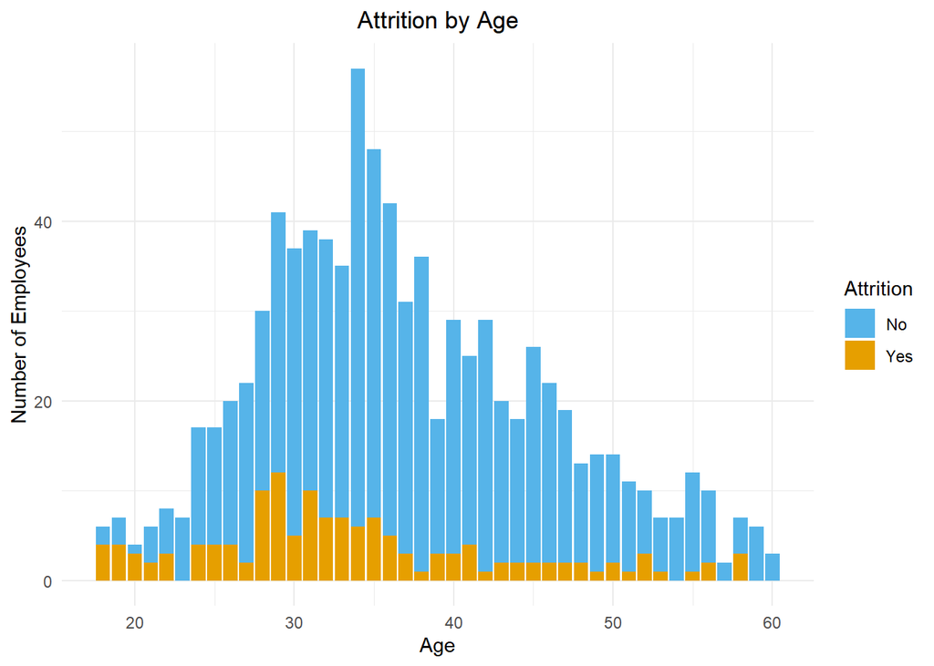

```r
#18 - 31 year olds have on average higher attrition rate than 32+
#26% of under 31 year olds attribute & only 12% of 32+ attribute
ggplot(Initial, aes(Age,fill=Attrition)) + geom_bar() + theme_minimal() + theme(plot.title = element_text(hjust=0.5)) + labs(x="Age", y="Number of Employees", title = "Attrition by Age") + scale_fill_manual(values = Palette)
```

```r
##prop.table(table(Initial$Attrition, Initial$Age),2)

#Create Age Group Bucket
Initial$AgeGroup <- with(Initial,ifelse(Age>31,"32 and Older ","Under 31"))

prop.table(table(Initial$Attrition, Initial$AgeGroup),2)
```

```
##
##       32 and Older   Under 31
##   No      0.8801314 0.7432950
##   Yes     0.1198686 0.2567050
```

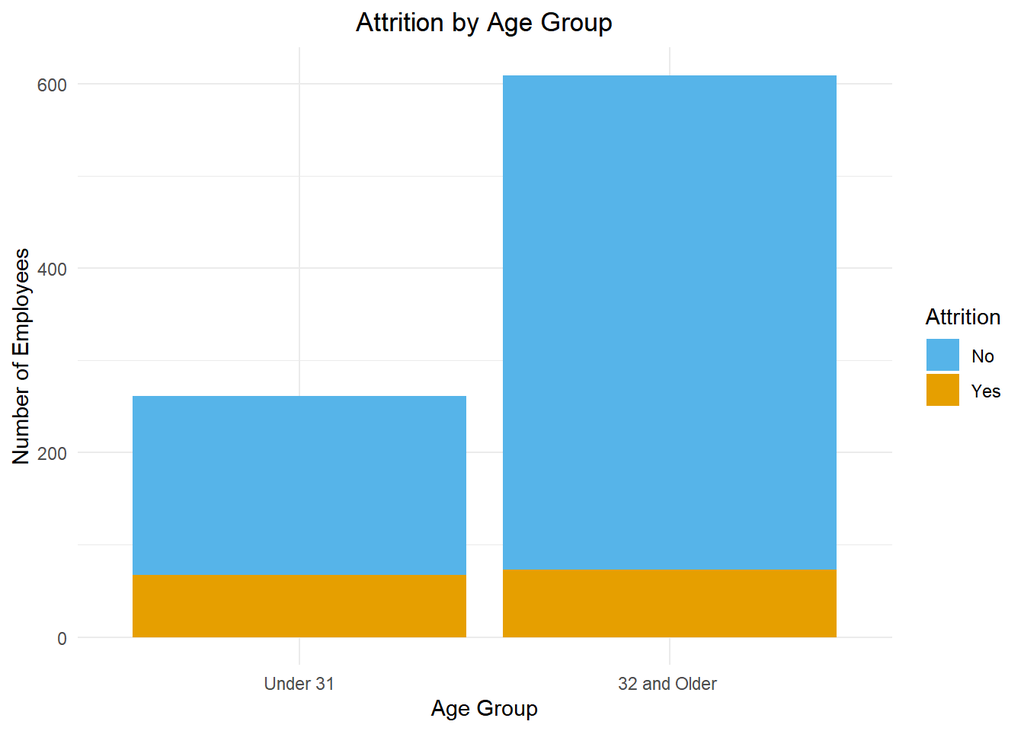

```r
ggplot(Initial, aes(x=reorder(AgeGroup,Age),fill=Attrition)) + geom_bar() + theme_minimal() + theme(plot.title = element_text(hjust=0.5)) + labs(x="Age Group", y="Number of Employees", title = "Attrition by Age Group") + scale_fill_manual(values = Palette)
```

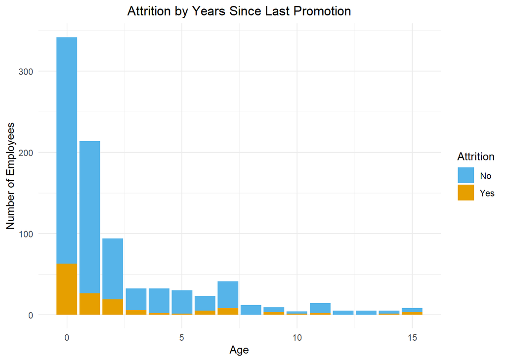

```r
#Years since last promotion
ggplot(Initial, aes(YearsSinceLastPromotion,fill=Attrition)) + geom_bar() + theme_minimal() + theme(plot.title = element_text(hjust=0.5)) + labs(x="Age", y="Number of Employees", title = "Attrition by Years Since Last Promotion") + scale_fill_manual(values = Palette)
```

```r
prop.table(table(Initial$Attrition, Initial$YearsSinceLastPromotion),2)
```

```
##
##                0          1          2          3          4          5
##   No  0.81578947 0.87850467 0.79787234 0.81250000 0.93750000 0.96666667
##   Yes 0.18421053 0.12149533 0.20212766 0.18750000 0.06250000 0.03333333
##
##                6          7          8          9         10         11
##   No  0.78260870 0.80487805 1.00000000 0.66666667 0.75000000 0.85714286
##   Yes 0.21739130 0.19512195 0.00000000 0.33333333 0.25000000 0.14285714
##
##               12         13         14         15
##   No  1.00000000 1.00000000 0.80000000 0.62500000
##   Yes 0.00000000 0.00000000 0.20000000 0.37500000
```

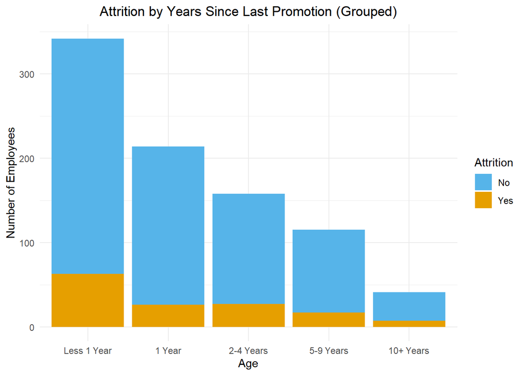

```r
#Creating a Promotion Bucket
Initial$PromotionGroup <- with(Initial,ifelse(YearsSinceLastPromotion>9,"10+ Years",ifelse(YearsSinceLastPromotion>4,"5-9 Years",ifelse(YearsSinceLastPromotion>1,"2-4 Years",ifelse(YearsSinceLastPromotion>0,"1 Year","Less 1 Year")))))

ggplot(Initial, aes(x=reorder(PromotionGroup,YearsSinceLastPromotion),fill=Attrition)) + geom_bar() + theme_minimal() + theme(plot.title = element_text(hjust=0.5)) + labs(x="Age", y="Number of Employees", title = "Attrition by Years Since Last Promotion (Grouped)") + scale_fill_manual(values = Palette)
```

```r
prop.table(table(Initial$Attrition, Initial$PromotionGroup),2)
```

```
##
##          1 Year 10+ Years 2-4 Years 5-9 Years Less 1 Year
##   No  0.8785047 0.8292683 0.8291139 0.8521739   0.8157895
##   Yes 0.1214953 0.1707317 0.1708861 0.1478261   0.1842105
```

```r
Initial$PromotionGroup2 <- with(Initial,ifelse(YearsSinceLastPromotion>9,"10+ Years",ifelse(YearsSinceLastPromotion>3,"4-9 Years","Less 4 Years")))

prop.table(table(Initial$Attrition, Initial$PromotionGroup2),2)
```

```
##
##       10+ Years 4-9 Years Less 4 Years
##   No  0.8292683 0.8707483    0.8328446
##   Yes 0.1707317 0.1292517    0.1671554
```

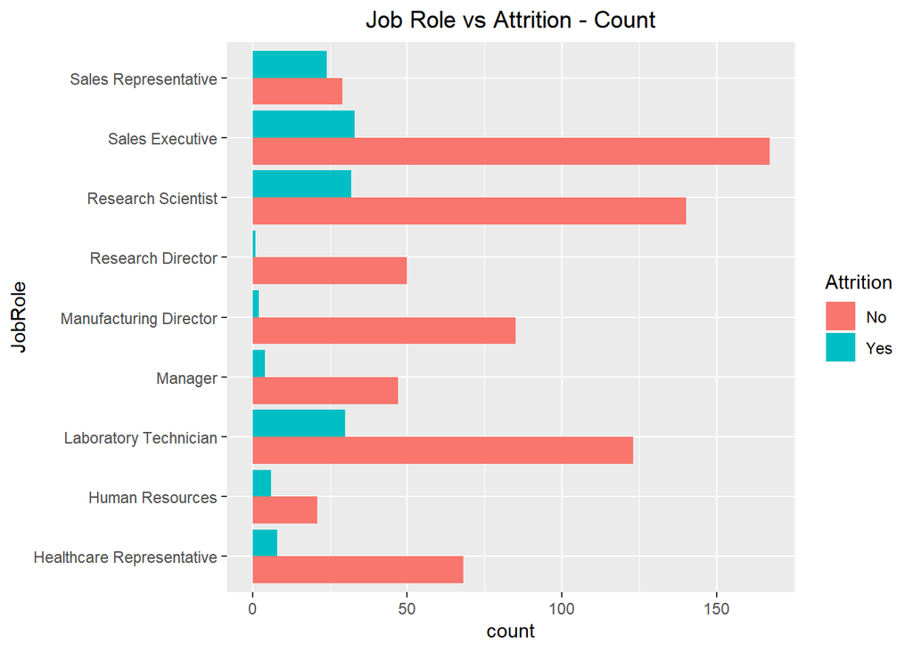

```r
# % of attrition by Job Role
ggplot(Initial,aes(x = JobRole,fill = Attrition)) +
  geom_bar(position = "dodge") +
    ggtitle("Job Role vs Attrition - Count") +
    coord_flip() +
    theme(plot.title = element_text(hjust = 0.5))
```

# Training & Test Set

```r
set.seed(7)
Set = sample(seq(1,dim(Initial)[1]),round(.60*dim(Initial)[1]),replace = FALSE)
#Training Set
Train = Initial[Set,]
#Test Set
Test = Initial[-Set,]

#Check to see if it pulled 60/40%
#dim(Test) 348  32
#dim(Train) 522  32
```

# KNN Model

K Nearest Neighbors Model is a classification model that compares inputs on their nearest neighbored inputs in order to classiy them in the correct grouping.

The accuracy for this model is around 84%; however, it does not meet the 60/60 sensitivity/specificity requirement.

```r
set.seed(7)

fit_knn <- train(Attrition~.,Train,method = 'knn',trControl = trainControl(method = 'repeatedcv',number = 3))

Predict_knn <- predict(fit_knn,Test)

confusionMatrix(Test$Attrition, Predict_knn)
```

```
## Confusion Matrix and Statistics
##
##           Reference
## Prediction  No Yes
##        No  293   6
##        Yes  48   1
##
##                Accuracy : 0.8448
##                  95% CI : (0.8024, 0.8812)
##     No Information Rate : 0.9799
##     P-Value [Acc > NIR] : 1
##
##                   Kappa : 5e-04
##
##  Mcnemar's Test P-Value : 2.414e-08
##
##             Sensitivity : 0.85924
##             Specificity : 0.14286
##          Pos Pred Value : 0.97993
##          Neg Pred Value : 0.02041
##              Prevalence : 0.97989
##          Detection Rate : 0.84195
##    Detection Prevalence : 0.85920
##       Balanced Accuracy : 0.50105
##
##        'Positive' Class : No
##
```

```r
#varImp(fit_knn)
```

Looking at KNN Model in a slightly different code form

```r
set.seed(7)
fit_knn2 <- train(Attrition~.,Train, method = "knn", preProcess = c("center", "scale"), tuneLength = 10)

Predict_knn2 <- predict(fit_knn2,Test)

confusionMatrix(Test$Attrition, Predict_knn2)
```

```
## Confusion Matrix and Statistics
##
##           Reference
## Prediction  No Yes
##        No  299   0
##        Yes  47   2
##
##                Accuracy : 0.8649
##                  95% CI : (0.8245, 0.899)
##     No Information Rate : 0.9943
##     P-Value [Acc > NIR] : 1
##
##                   Kappa : 0.0681
##
##  Mcnemar's Test P-Value : 1.949e-11
##
##             Sensitivity : 0.86416
##             Specificity : 1.00000
##          Pos Pred Value : 1.00000
##          Neg Pred Value : 0.04082
##              Prevalence : 0.99425
##          Detection Rate : 0.85920
##    Detection Prevalence : 0.85920
##       Balanced Accuracy : 0.93208
##
##        'Positive' Class : No
##
```

```r
#varImp(fit_knn2)
```

#Naive Bayes Model Naive Bayes tries to classify instances based on the probabilities of previously seen attributes/instances, assuming complete attribute independence.

The accuracy for this model is around 86%; however, it does not meet the 60/60 sensitivity/specificity requirement.

```r
library(naivebayes)
set.seed(7)
fit_nb <- train(Attrition~.,Train,method = 'naive_bayes',trControl = trainControl(method = 'repeatedcv',number = 3))

Predict_nb <- predict(fit_nb,Test)

confusionMatrix(Test$Attrition, Predict_nb)
```

```
## Confusion Matrix and Statistics
##
##           Reference
## Prediction  No Yes
##        No  299   0
##        Yes  49   0
##
##                Accuracy : 0.8592
##                  95% CI : (0.8182, 0.894)
##     No Information Rate : 1
##     P-Value [Acc > NIR] : 1
##
##                   Kappa : 0
##
##  Mcnemar's Test P-Value : 7.025e-12
##
##             Sensitivity : 0.8592
##             Specificity :     NA
##          Pos Pred Value :     NA
##          Neg Pred Value :     NA
##              Prevalence : 1.0000
##          Detection Rate : 0.8592
##    Detection Prevalence : 0.8592
##       Balanced Accuracy :     NA
##
##        'Positive' Class : No
##
```

```r
#varImp(fit_nb)
```

# General Logistic Regression Model

```r
set.seed(7)
model <- glm(Attrition ~ Age+BusinessTravel+Department+DistanceFromHome+
               Education+EducationField+EnvironmentSatisfaction+Gender+JobInvolvement+
               JobLevel+JobRole+JobSatisfaction+MaritalStatus+MonthlyIncome+NumCompaniesWorked+
               OverTime+PercentSalaryHike+PerformanceRating+RelationshipSatisfaction+
               TotalWorkingYears+TrainingTimesLastYear+WorkLifeBalance+
               YearsAtCompany+YearsInCurrentRole+YearsSinceLastPromotion+
               YearsWithCurrManager,family=binomial(link='logit'),data=Train)

summary(model)
```

```
##
## Call:
## glm(formula = Attrition ~ Age + BusinessTravel + Department +
##     DistanceFromHome + Education + EducationField + EnvironmentSatisfaction +
##     Gender + JobInvolvement + JobLevel + JobRole + JobSatisfaction +
##     MaritalStatus + MonthlyIncome + NumCompaniesWorked + OverTime +
##     PercentSalaryHike + PerformanceRating + RelationshipSatisfaction +
##     TotalWorkingYears + TrainingTimesLastYear + WorkLifeBalance +
##     YearsAtCompany + YearsInCurrentRole + YearsSinceLastPromotion +
##     YearsWithCurrManager, family = binomial(link = "logit"),
##     data = Train)
##
## Deviance Residuals:
##     Min       1Q   Median       3Q      Max
## -1.7172  -0.4817  -0.2301  -0.0597   3.0355
##
## Coefficients:
##                                    Estimate Std. Error z value Pr(>|z|)
## (Intercept)                      -1.188e+01  8.462e+02  -0.014 0.988801
## Age                              -1.449e-02  2.243e-02  -0.646 0.518074
## BusinessTravelTravel_Frequently   1.319e+00  6.737e-01   1.958 0.050267
## BusinessTravelTravel_Rarely       7.906e-01  5.880e-01   1.345 0.178777
## DepartmentResearch & Development  1.477e+01  8.462e+02   0.017 0.986069
## DepartmentSales                   1.479e+01  8.462e+02   0.017 0.986051
## DistanceFromHome                  5.713e-02  1.951e-02   2.929 0.003400
## Education                        -6.444e-02  1.509e-01  -0.427 0.669357
## EducationFieldLife Sciences      -1.507e+00  1.296e+00  -1.163 0.244801
## EducationFieldMarketing          -1.241e+00  1.404e+00  -0.884 0.376934
## EducationFieldMedical            -1.737e+00  1.298e+00  -1.338 0.180935
## EducationFieldOther              -5.695e-01  1.364e+00  -0.418 0.676312
## EducationFieldTechnical Degree   -5.438e-01  1.330e+00  -0.409 0.682569
## EnvironmentSatisfaction          -3.672e-01  1.469e-01  -2.499 0.012464
## GenderMale                        4.482e-01  3.188e-01   1.406 0.159683
## JobInvolvement                   -7.758e-01  2.163e-01  -3.587 0.000334
## JobLevel                         -8.223e-01  5.904e-01  -1.393 0.163672
## JobRoleHuman Resources            1.540e+01  8.462e+02   0.018 0.985479
## JobRoleLaboratory Technician      1.037e+00  8.543e-01   1.214 0.224608
## JobRoleManager                    2.097e-02  1.586e+00   0.013 0.989455
## JobRoleManufacturing Director    -1.908e+00  1.245e+00  -1.533 0.125394
## JobRoleResearch Director         -1.332e+00  1.532e+00  -0.869 0.384612
```

[output cut: 56 more lines]

```
## WorkLifeBalance
## YearsAtCompany                   *
## YearsInCurrentRole               *
## YearsSinceLastPromotion          ***
## YearsWithCurrManager             *
## ---
## Signif. codes:  0 '***' 0.001 '**' 0.01 '*' 0.05 '.' 0.1 ' ' 1
##
## (Dispersion parameter for binomial family taken to be 1)
##
##     Null deviance: 483.04  on 521  degrees of freedom
## Residual deviance: 302.76  on 481  degrees of freedom
## AIC: 384.76
##
## Number of Fisher Scoring iterations: 15
```

```r
Predictions_logreg <- predict(model, Test)

#Tranform the “Yes” and “No” to binary variables
Test_logreg <- Test  %>% mutate(ModelPredictions = 1*(Predictions_logreg > .50) + 0,
                                 BinaryAtt = 1*(Attrition == "Yes") + 0)
#Compare the newly created columns “model_pred” and “visit_binary” to calculate the accuracy of our model
Final <- Test_logreg %>% mutate(accurate = 1*(ModelPredictions == BinaryAtt))
#Accuracy Score
sum(Final$accurate)/nrow(Final)
```

```
## [1] 0.9051724
```

# Decision Tree Model

While this model has an 86% accuracy, it was unable to predict any of the attrition (Y) correctly, so it has a zero on Specificity.

```r
set.seed(7)
fit_rpart <- train(Attrition ~.,Train,method = 'rpart', trControl = trainControl(method = 'cv',number = 3))
Predictions_rpart <- predict(fit_rpart,Test)
confusionMatrix(Test$Attrition, Predictions_rpart)
```

```
## Confusion Matrix and Statistics
##
##           Reference
## Prediction  No Yes
##        No  299   0
##        Yes  49   0
##
##                Accuracy : 0.8592
##                  95% CI : (0.8182, 0.894)
##     No Information Rate : 1
##     P-Value [Acc > NIR] : 1
##
##                   Kappa : 0
##
##  Mcnemar's Test P-Value : 7.025e-12
##
##             Sensitivity : 0.8592
##             Specificity :     NA
##          Pos Pred Value :     NA
##          Neg Pred Value :     NA
##              Prevalence : 1.0000
##          Detection Rate : 0.8592
##    Detection Prevalence : 0.8592
##       Balanced Accuracy :     NA
##
##        'Positive' Class : No
##
```